## Stat 523

### Assignment 4: One-Way S3 Implementation

#### Explain your code where appropriate.

#### Doug Raffle (dcraffle@mix.wvu.edu)

You should turn in this .Rmd file as well as the corresponding .html file. I should be able to execute the .Rmd file. You may want to develop the code using a separate .R file. You may want to add arguments to some of the functions below, e.g., alpha = 0.05 for testing.

Develop an S3 class to estimate the relevant parameters in a one-way AOV with possibly unequal sample sizes (e.g., see Dowdy and Wearden, Statistics for Research, Wiley). You can use some of the code from Assignment 2.

#### 1. Develop a default method, **oneway.default**, for the generic function **oneway**.

```r
oneway <- function(z, ...) UseMethod("oneway")

oneway.default <- function(z, ...) {
    ## Make sure we're the right data structure
    if(!is.list(z) | is.data.frame(z)){
        stop("data structure is not one of:\nlist, factor & vector, or formula")
    }
    ## computing formulas
    a <- length(z)
    N <- length(unlist(z))
    TT <- sum(unlist(z)^2)
    A <- sum(sapply(z, function(x) sum(x)^2/length(x)))
    CF <- sum(unlist(z))^2/N
    ## computes SS's and DF's
    ss.a <- A - CF ## within
    ss.e <- TT - A ## between
    df.a <- a - 1
    df.e <- N - a
    ## get LS Means & sample sizes
    ybar.vec <- unlist(lapply(z, mean))
    n.vec <- unlist(lapply(z, length))
    ## find group names
    if(is.null(names(z))){
        groups <- as.character(1:length(z))
    }
    else{
        groups <- names(z)
    }
    names(ybar.vec) <- groups
    ## create object, add class, & return
    res <- list(df = c(df.a, df.e), SS = c(ss.a, ss.e),
                groups = groups, call = match.call(), data = z,
                ls.means = ybar.vec, n.vec = n.vec, N = N, a = a)
    class(res) <- "oneway"
    return(res)
}
```

The *z* argument for **oneway.default** should be a list of (possibly) named components, one for each sample. The computations for the one-way ANOVA should be done in **oneway.default**.

#### 2. This method uses the more standard input of a factor representing groups (or samples) and a numeric response.

```r
oneway.factor <- function(z, y, ...) {
    foo <- oneway.default(split(y, z))
    foo$call <- match.call()
    foo
}
```

The *z* argument should be the factor with levels representing samples. The factor should be used to deconstruct *y*, the response, into a list as in the default.

#### 3. The model formula is the standard for R models, but do not use **model.matrix** to implement **oneway**.

```r
oneway.formula <- function(formula, data=list(), ...) {
    mf <- model.frame(formula, data)
    foo <- oneway.factor(mf[,2], mf[,1])
    foo$call <- match.call()
    foo
}
```

You might want to extract the factor term and the response from the **model.frame** and then call **oneway.factor**, which in turn calls **oneway.default**.

#### 4. The default **print** method should be short and provide essential information.

```r
print.oneway <- function(x, ...) {
   print(x$call)
   cat("\nWithin SS:", x$SS[1], "on", x$df[1],
       "degrees of freedom.\n")
   cat("Between SS:", x$SS[2], "on", x$df[2],
       "degrees of freedom.\n")
}
```

#### 5. The summary method should create a summary object—not print directly.

```r
summary.oneway <- function(object, ...) {
    attach(object)
    ## Get total SS & df
    ss.t <- SS[1] + SS[2]
    df.t <- df[1] + df[2]
    ## Calculate mean squares
    ms.a <- SS[1]/df[1]
    ms.e <- SS[2]/df[2]
    ## get F stat & p-val
    F <- ms.a/ms.e
    p <- pf(F, df[1], df[2], lower.tail = FALSE)

    ## construct AOV table
    tab <- with(object, cbind(DF = c(df, df.t),
                         SS = c(SS, ss.t),
                         MS = c(ms.a, ms.e, NA),
                         F = c(F, NA, NA),
                         "Pr(>F)" = c(p, NA, NA)))
    rownames(tab) <- c("Among Groups", "Within Groups (error)",
                       "Total")
    res <- list(call=call, tab=tab, groups=groups, ls.means=ls.means,
                P = p, MS = c(ms.a, ms.e), n.vec = n.vec, N = N, a = a)
    class(res) <- "summary.oneway"
    detach(object)
    return(res)
}
```

The argument is a **oneway** object. The summary object should include a component representing an AOV table, e.g., see Dowdy and Wearden. You might want to decide whether objects of class *summary.oneway* inherit from the class *oneway*.

#### 6. The print method for the summary object should provide more detailed information about the summary object.

```r
print.summary.oneway <- function(x, ...) {
    ## function call
    cat("Call:\n\t")
    print(x$call)
    ## LS means
    cat("\nMeans:\n")
    print(x$ls.means)
    cat("\n")
    # AOV Table
    cat("\nAnalysis of Variance Table:\n")
    printCoefmat(x$tab, P.values=TRUE, has.Pvalue=TRUE, signif.stars=TRUE, na.print="")
}
```

The AOV table should be formatted nicely. The least squares means should also be formated and printed.

#### 7. Implement Fisher’s LSD multiple comparison procedure for your oneway.

```r
lsmeans <- function(x, ...) UseMethod("lsmeans")
lsmeans.default <- function(object, ...){
    if(!(class(object)=="oneway")){
        stop("lsmeans only accepts class \"oneway\"")
    }
}
lsmeans.oneway <- function(object, ...) {
    object <- summary(object)
    if(object$P > 0.05){
        warning("F-test is not significant at alpha=0.05.")
    }
    compare <- function(i, j){
        d <- object$ls.means[i] - object$ls.means[j]
        s.e <- sqrt(object$MS[2]*(1/object$n.vec[i] + 1/object$n.vec[j]))
        t.val <- d/s.e
        round(2*pt(abs(t.val), object$N-object$a, lower.tail=FALSE),4)
    }
    p.vals <- pairwise.table(compare.levels=compare,
                             level.names=object$groups,
                             p.adjust.method="none")
    result <- list(p.value=p.vals, call=match.call())
    class(result) <- "lsmeans"
    result
}
print.lsmeans <- function(x, ...){
    cat("Call:\n\t")
    print(x$call)
    cat("\nFisher's LSD Table\n")
    cat("\nP-Values:\n")
    print.table(x$p.value, na.print="-")
}
```

The argument is a *oneway* object, which should include the least-squares means as a component. Fisher’s LSD should be computed and formatted nicely.

#### 8. A plot generic function should be implemented for *oneway* objects.

```r
plot.oneway <- function(x, names=x$groups, xlab="Group", ylab="Response", main=capture.output(x$call), ...){
    boxplot(x=x$data, names=names, xlab=xlab, ylab=ylab, main=main, ...)
}
```

The plot should compare the distributions of the groups in a side-by-side manner.

#### 9. Your S3 class implementation should be illustrated with the *coagulation* data set. The data consists of blood coagulation times for 24 animals randomly assigned to four different diets.

```r
## load data
library(faraway)
data(coagulation)
coagulation[1:4,]
```

```
##   coag diet
## 1   62    A
## 2   60    A
## 3   63    A
## 4   59    A
```

```r
attach(coagulation)
```

First, we can examine the default print function for the 3 default data structures.

```r
by.diet <- split(x = coag, f = diet)
oneway(z = by.diet)
```

```
## oneway.default(z = by.diet)
##
## Within SS: 228 on 3 degrees of freedom.
## Between SS: 112 on 20 degrees of freedom.
```

```r
oneway(z = diet, y = coag)
```

```
## oneway.factor(z = diet, y = coag)
##
## Within SS: 228 on 3 degrees of freedom.
## Between SS: 112 on 20 degrees of freedom.
```

```r
oneway(formula = coag ~ diet, data = coagulation)
```

```
## oneway.formula(formula = coag ~ diet, data = coagulation)
##
## Within SS: 228 on 3 degrees of freedom.
## Between SS: 112 on 20 degrees of freedom.
```

We can see that each method produces the same sums of squares and degrees of freedom, which we could use to construct our F statistic.

Next, we can see the full analysis of variance table using the `summary()` function.

```r
coag.oneway <- oneway(by.diet)
summary(coag.oneway)
```

```
## Call:
##  oneway.default(z = by.diet)
##
## Means:
##  A  B  C  D
## 61 66 68 61
##
##
## Analysis of Variance Table:
##                          DF    SS    MS      F    Pr(>F)
## Among Groups            3.0 228.0  76.0 13.571 4.658e-05 ***
## Within Groups (error)  20.0 112.0   5.6
## Total                  23.0 340.0
## ---
## Signif. codes:  0 '***' 0.001 '**' 0.01 '*' 0.05 '.' 0.1 ' ' 1
```

Finally, we can examine Fisher’s LSD table and visualize it using the plot function.

```r
lsmeans(coag.oneway)
```

```
## Call:
##  lsmeans.oneway(object = coag.oneway)
##
## Fisher's LSD Table
##
## P-Values:
##        A      B      C
## B 0.0038      -      -
## C 0.0002 0.1588      -
## D 1.0000 0.0009 0.0000
```

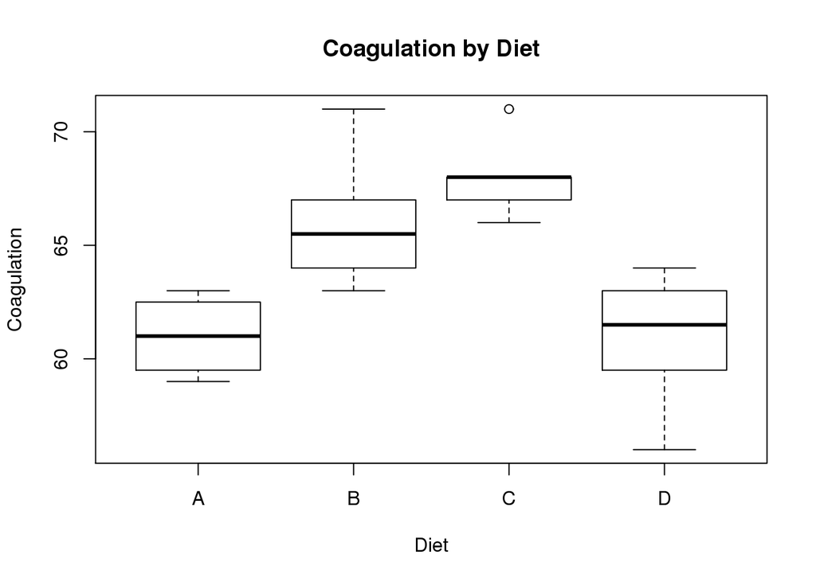

```r
plot(coag.oneway, xlab = "Diet", ylab = "Coagulation", main = "Coagulation by Diet")
```

You should provide brief explanations of the output along with the output, which implies that you may want multiple chucks of R code interspersed with markdown.

```r
detach(coagulation)
```